# Survival analysis

## Overview

*Survival analysis* focuses on describing for a given individual or group of individuals, a defined point of **an event** *occurrence of a disease, cure from a disease, death, relapse after response to treatment_…*) that occurs after **a period of time** called **time-to-event"** during which individuals are observed. To determine the **time-to-event"**, it is then necessary to define a time of origin (that can be the inclusion date, the date of diagnosis…).

The target of inference for survival analysis is then the time between an origin and an event.

It is usually expressed through the *survival probability* which is the probability that the event of interest has not occurred by a duration *t*.

*Censoring*: Censoring occurs when at the end of follow-up, some of the individuals have not had the event of interest, and thus their true time to event is unknown. We will mostly focus on right censoring (which occurs when we are missing information for a subject after a certain point in time) here but for more details on censoring and survival analysis in general, you can see references.

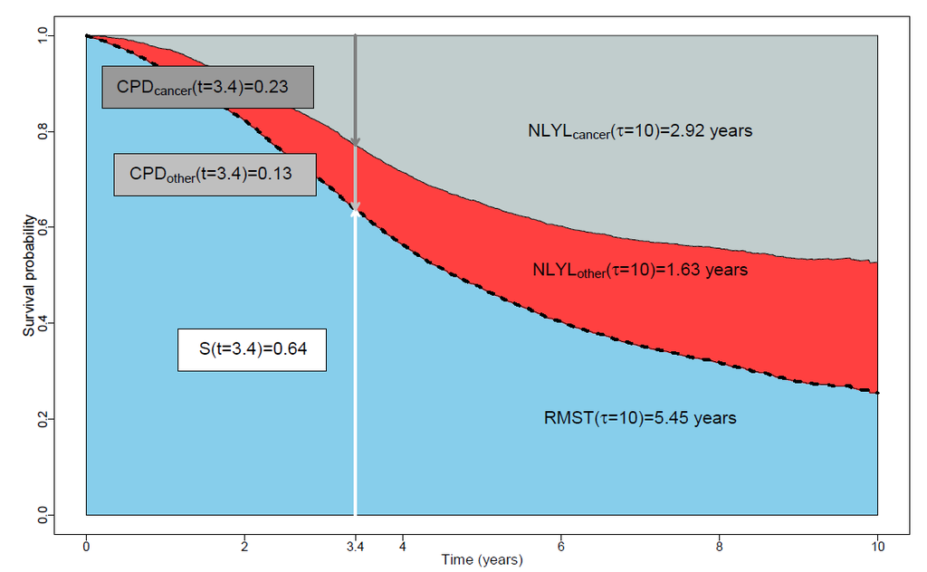

## Preparation

### Load packages

In this handbook we emphasize `p_load()` from **pacman**, which installs the package if necessary and loads it for use. You can also load packages with `library()` from **base** R. See the page on [R basics] for more information on R packages.

This page explores survival analyses using the linelist used in most of the previous pages and on which we apply some changes to have a proper survival data.

### Import dataset

We import the dataset of cases from a simulated Ebola epidemic. If you want to download the data to follow step-by-step, see instructions in the [Download book and data] page. The dataset is imported using the `import()` function from the **rio** package. See the page on [Import and export] for various ways to import data.

```r
# import linelist
linelist_case_data <- rio::import("linelist_cleaned.xlsx")
```

### Data management and transformation

In short, survival data can be described as having the following three characteristics:

1. the dependent variable or response is the waiting time until the occurrence of a well-defined event,
2. observations are censored, in the sense that for some units the event of interest has not occurred at the time the data are analyzed, and
3. there are predictors or explanatory variables whose effect on the waiting time we wish to assess or control.

Thus, we will create different variables needed to respect that structure and run the survival analysis.

We define:

- our event of interest as being “death” (hence our survival probability will be the probability of being alive after a certain time after the time of origin),
- the follow-up time (`futime`) as the time between the time of onset and the time of outcome *in days*,
- censored patients as those who recovered or for whom the final outcome is not known ie the event “death” was not observed (`event=0`).

*CAUTION:* Since in a real cohort study, the information on the time of origin and the end of the follow-up is known given individuals are observed, we will remove observations where the date of onset or the date of outcome is unknown. Also the cases where the date of onset is later than the date of outcome will be removed since they are considered as wrong.

*TIP:* Given that filtering to greater than (>) or less than (<) a date can remove rows with missing values, applying the filter on the wrong dates will also remove the rows with missing dates.

We then create from the var `age_cat` another variable `age_cat_small` that indicates reduces the categories of the age groups to 3.

```r
#create a new data called linelist_surv from the linelist_case_data

linelist_surv <-  linelist_case_data %>%

  dplyr::filter(
       # remove observations with wrong or missing dates of onset or date of outcome
       date_outcome > date_onset) %>%

  dplyr::mutate(
       # create the event var which is 1 if the patient died and 0 if he was right censored
       event = ifelse(is.na(outcome) | outcome == "Recover", 0, 1),

       # create the var on the follow-up time in days
       futime = as.double(date_outcome - date_onset),

       # create a new age category variable with only 3 strata levels
       age_cat_small = dplyr::case_when(
            age_years < 5  ~ "0-4",
            age_years >= 5 & age_years < 20 ~ "5-19",
            age_years >= 20   ~ "20+"),

       # previous step created age_cat_small var as character.
       # now convert it to factor and specify the levels.
       # Note that the NA values remain NA's and are not put in a level "unknown" for example,
       # since in the next analyses they have to be removed.
       age_cat_small = factor(age_cat_small,
                              levels = c("0-4", "5-19", "20+")))
```

*TIP:* It is a good habit communicating on the median follow-up time (time-to-event) when interpreting survival analysis results: it can be checked by doing a `summary()` on the `futime`. Besides this, it is also globally recommended to verify the new variables we have created. Here, you can do a verification by doing a cross-tabulation between `event` and `outcome` from which it was created (*not shown here*).

```
##    Min. 1st Qu.  Median    Mean 3rd Qu.    Max.
##    1.00    6.00   10.00   11.98   16.00   64.00
```

After this data management step, we can print the 20 first observations of our new dataset looking at specific variables (including those newly created).

| case_id | generation | date_infection | date_onset | date_hospitalisation | date_outcome | outcome | gender | age | age_unit | age_years | age_cat | age_cat5 | hospital | lon | lat | infector | source | wt_kg | ht_cm | ct_blood | fever | chills | cough | aches | vomit | temp | time_admission | bmi | days_onset_hosp | … |
| --- | --- | --- | --- | --- | --- | --- | --- | --- | --- | --- | --- | --- | --- | --- | --- | --- | --- | --- | --- | --- | --- | --- | --- | --- | --- | --- | --- | --- | --- | --- |
| 8689b7 | 4 |  | 2014-05-13 | 2014-05-14 | 2014-05-18 | Recover | f | 3 | years | 3 | 0-4 | 0-4 | Missing | -13.2152339775486 | 8.45171855856465 |  |  | 25 | 59 | 22 |  |  |  |  |  | 36.9 | 09:36 | 71.8184429761563 | 1 | … |
| 11f8ea | 2 |  | 2014-05-16 | 2014-05-18 | 2014-05-30 | Recover | m | 56 | years | 56 | 50-69 | 55-59 | St. Mark's Maternity Hospital (SMMH) | -13.212910703914 | 8.46481700596819 |  |  | 91 | 238 | 21 |  |  |  |  |  | 36.9 | 16:48 | 16.0652496292635 | 2 | … |
| 893f25 | 3 | 2014-05-18 | 2014-05-21 | 2014-05-22 | 2014-05-29 | Recover | m | 3 | years | 3 | 0-4 | 0-4 | Military Hospital | -13.2228638912441 | 8.46082377490923 | 11f8ea | other | 36 | 71 | 23 | no | no | yes | no | yes | 36.9 | 12:60 | 71.4144019043841 | 1 | … |
| be99c8 | 3 | 2014-05-03 | 2014-05-22 | 2014-05-23 | 2014-05-24 | Recover | f | 16 | years | 16 | 15-19 | 15-19 | Port Hospital | -13.222625321098 | 8.46183062600728 | aec8ec | other | 56 | 116 | 21 | no | no | yes | no | yes | 37.6 | 14:13 | 41.6171224732461 | 1 | … |
| 07e3e8 | 4 | 2014-05-22 | 2014-05-27 | 2014-05-29 | 2014-06-01 | Recover | f | 16 | years | 16 | 15-19 | 15-19 | Missing | -13.2331547837254 | 8.46272931462646 | 893f25 | other | 47 | 87 | 21 |  |  |  |  |  | 37.3 | 14:33 | 62.0953890870657 | 2 | … |
| 369449 | 4 | 2014-05-28 | 2014-06-02 | 2014-06-03 | 2014-06-07 | Death | f | 0 | years | 0 | 0-4 | 0-4 | Missing | -13.2320975453153 | 8.46144367534271 | 133ee7 | other | 0 | 11 | 22 | no | no | yes | no | yes | 37 | 09:25 | 0 | 1 | … |
| f393b4 | 4 |  | 2014-06-05 | 2014-06-06 | 2014-06-18 | Recover | m | 61 | years | 61 | 50-69 | 60-64 | Missing | -13.2225511595637 | 8.46191259217774 |  |  | 86 | 226 | 22 | no | no | yes | no | yes | 36.4 | 11:16 | 16.8376536925366 | 1 | … |
| 1389ca | 4 |  | 2014-06-05 | 2014-06-07 | 2014-06-09 | Death | f | 27 | years | 27 | 20-29 | 25-29 | Missing | -13.2572163655863 | 8.47292327643506 |  |  | 69 | 174 | 22 | no | no | yes | no | no | 35.9 | 10:55 | 22.7903289734443 | 2 | … |
| 2978ac | 4 | 2014-05-30 | 2014-06-06 | 2014-06-08 | 2014-06-15 | Death | m | 12 | years | 12 | 10-14 | 10-14 | Port Hospital | -13.2206286746001 | 8.48401630165138 | 996f3a | other | 67 | 112 | 22 | no | no | yes | no | yes | 36.5 | 16:03 | 53.4119897959184 | 2 | … |
| fc15ef | 6 | 2014-06-14 | 2014-06-16 | 2014-06-17 | 2014-07-09 | Recover | m | 19 | years | 19 | 15-19 | 15-19 | Missing | -13.2385127873491 | 8.47761705512509 | 37a6f6 | other | 68 | 174 | 22 | no | no | yes | no | no | 36.5 | 12:42 | 22.4600343506408 | 1 | … |

[output cut: 10 more lines]

## Basics of survival analysis

### Building a surv-type object

We will first use `Surv()` to build a standard survival object form the follow-up time and the event variables.The result of such a step is to produce an object of type *survival* that focuses on the time information by precising whether or not the event of interest (death) was observed. This is done using a “+” after the time in the print out of *survobj* that indicates right-censoring (*see definition of survival probability above and references*).

```r
survobj <- with(linelist_surv,

                survival::Surv(futime, event)

                )

#print the 50 first elements of the vector to see how it presents

 head(survobj,50)
```

```
##  [1]  5+ 14+  8+  2+  5+  5  13+  4   9  23+ 12+ 22+  9+  2+ 11   6  11+  5+ 12+
## [20] 13   6+  2   8   3+  6  13+  4   9  28+ 14+  4  37+  6+  9+  7  43+  2   4
## [39]  5+ 13   6+ 19+ 20+  9   7  32+  6   4  19+ 15+
```

### Running initial analyses

We then start our analysis using the `survfit()` function to produce a *survfit object*, which fits the default calculations for *Kaplan Meier* (KM) estimates of the overall (marginal) survival curve, which are in fact a step function with jumps at observed event times. The final *survfit object* contains one or more survival curves and is created using the *Surv object* as a response variable in the model formula.

*NOTE:* The Kaplan-Meier estimate is a nonparametric maximum likelihood estimate (MLE) of the survival function. . (see resources for more information).

The summary of this *survfit object* will give what is called a *life table* that contains:

- for each of the time of the follow-up (`time`) where an event happened and that are ascending ordered,
- the number of people who were at risk of developing the event (people who did not have the event yet nor were censored: `n.risk`),
- those who did develop it (`n.event`),
- and from this, the probability of not developing the event (probability of not dying or of surviving past that specific time ).
- Finally the standard error and the confidence interval for that probability are derived.

```r
#fit the KM estimates using the formula where the previously Surv object "survobj" is the response variable. "~ 1" precises we run the model for the overall survival.

linelistsurv_fit <-  survival::survfit(
  survobj ~ 1
  )

#print its summary for more details
summary(linelistsurv_fit)
```

```
## Call: survfit(formula = survobj ~ 1)
##
##  time n.risk n.event survival std.err lower 95% CI upper 95% CI
##     1   4539      30    0.993 0.00120        0.991        0.996
##     2   4500      69    0.978 0.00217        0.974        0.982
##     3   4394     149    0.945 0.00340        0.938        0.952
##     4   4176     194    0.901 0.00447        0.892        0.910
##     5   3899     214    0.852 0.00535        0.841        0.862
##     6   3592     210    0.802 0.00604        0.790        0.814
##     7   3223     179    0.757 0.00656        0.745        0.770
##     8   2899     167    0.714 0.00700        0.700        0.728
##     9   2593     145    0.674 0.00735        0.660        0.688
##    10   2311     109    0.642 0.00761        0.627        0.657
##    11   2081     119    0.605 0.00788        0.590        0.621
##    12   1843      89    0.576 0.00809        0.560        0.592
```

[output cut: 17 more lines]

While using `summary()` we can add the option `times` and precise the specific times at which we want to see the survival information

```r
#print its summary at specific times
sum_fit_detailed <- summary(
  linelistsurv_fit,
        times=c(5,10,20,30,60)
        )

sum_fit_detailed
```

```
## Call: survfit(formula = survobj ~ 1)
##
##  time n.risk n.event survival std.err lower 95% CI upper 95% CI
##     5   3899     656    0.852 0.00535        0.841        0.862
##    10   2311     810    0.642 0.00761        0.627        0.657
##    20    705     446    0.472 0.00911        0.454        0.490
##    30    210      39    0.435 0.01030        0.415        0.455
##    60      2       1    0.429 0.01175        0.406        0.452
```

We can also use the `print()` function. The `print.rmean=TRUE` argument is used to obtain the mean survival time and its standard error (se).

*NOTE:* The restricted mean survival time (RMST) is a specific survival measure more and more used in cancer survival analysis and which is often defined as the area under the survival curve given we observe patients up to restricted time T: more details in resources

```r
#print the linelistsurv_fit object and ask for information on the mean survival time and its se.
print(
  linelistsurv_fit,
      print.rmean = TRUE
      )
```

```
## Call: survfit(formula = survobj ~ 1)
##
##          n     events     *rmean *se(rmean)     median    0.95LCL    0.95UCL
##   4539.000   1952.000     33.105      0.539     17.000     16.000     18.000
##     * restricted mean with upper limit =  64
```

*TIP:* We can create the *surv object* directly in the `survfit()` function and save a line of code. This will then give `linelistsurv_quick <- survfit(Surv(futime, event) ~ 1, data=linelist_surv)`. But as you have seen, in such case we have to precise the data where the variables time and event are taken from.

Besides the `summary()` function, we can also use the `str()` function that gives more details on the structure of the `survfit()` object. Among those details is an important one: *cumhaz* which allows for instance to plot the *cumulative hazard*, with the *hazard* being the *instantaneous rate of event occurrence* (see references).

```r
print(
  str(linelistsurv_fit)
      )
```

```
## List of 16
##  $ n        : int 4539
##  $ time     : num [1:59] 1 2 3 4 5 6 7 8 9 10 ...
##  $ n.risk   : num [1:59] 4539 4500 4394 4176 3899 ...
##  $ n.event  : num [1:59] 30 69 149 194 214 210 179 167 145 109 ...
##  $ n.censor : num [1:59] 9 37 69 83 93 159 145 139 137 121 ...
##  $ surv     : num [1:59] 0.993 0.978 0.945 0.901 0.852 ...
##  $ std.err  : num [1:59] 0.00121 0.00222 0.00359 0.00496 0.00628 ...
##  $ cumhaz   : num [1:59] 0.00661 0.02194 0.05585 0.10231 0.15719 ...
##  $ std.chaz : num [1:59] 0.00121 0.00221 0.00355 0.00487 0.00615 ...
##  $ type     : chr "right"
##  $ logse    : logi TRUE
##  $ conf.int : num 0.95
##  $ conf.type: chr "log"
##  $ lower    : num [1:59] 0.991 0.974 0.938 0.892 0.841 ...
##  $ upper    : num [1:59] 0.996 0.982 0.952 0.91 0.862 ...
##  $ call     : language survfit(formula = survobj ~ 1)
##  - attr(*, "class")= chr "survfit"
## NULL
```

### Plotting Kaplan-Meir curves

Once the KM estimates are fitted, we can visualize that probability of being alive through the time using the basic `plot()` function that draws the so-known “Kaplan-Meier curve”. In other words the curve below is a conventional illustration of the survival experience in the whole patient group.

*TIP:* Besides the **base** R `plot()`, other packages allow plotting of KM curves as well, such as *survminer* and its `ggsurvplot()`

We can easily verify the follow-up time min and max on the curve.

An easy way to interpret it is to say that at time zero, all the participants are still alive: survival probability is then 100%. Then it decreases over time as patients die. The proportion of participants surviving past 60 days of f-u is around 40%.

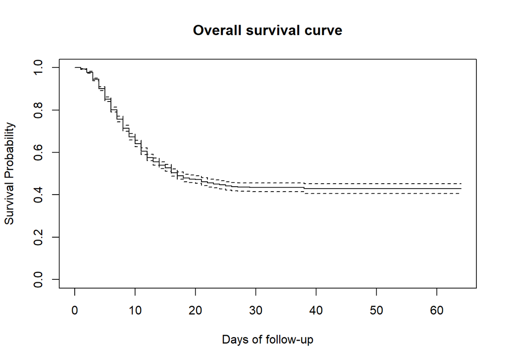

```r
plot(linelistsurv_fit,
     xlab = "Days of follow-up",    #xaxis label
     ylab="Survival Probability",   #yaxis label
     main= "Overall survival curve" #figure title
     )
```

The confidence interval of the KM estimates of the survival are also plotted by default and can be dismissed by adding the option `conf.int=FALSE` to the `plot()` command.

Since the event of interest is “death”, drawing a curve describing the complements of the survival proportions will lead to drawing the cumulative mortality proportions.

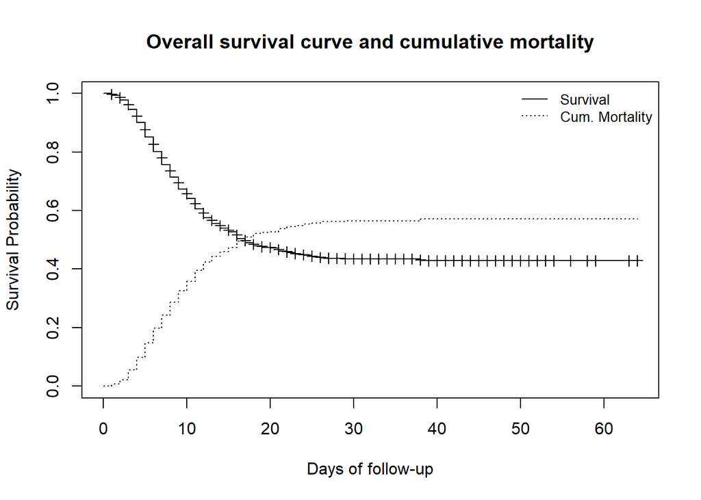

```r
plot(
     linelistsurv_fit,
     xlab = "Days of follow-up",
     ylab="Survival Probability",
     mark.time=TRUE,              #mark times of events to facilitate reading of the curve: a "+" sign is printed on the curve at every event
     conf.int=FALSE,             #do not plot the confidence interval
     main= "Overall survival curve and cumulative mortality"
     )



#draw an additional curve to the previous plot
lines(
      linelistsurv_fit,
      lty=3,          #use a different line type to differenciate between the two curves and for legend clarity purposes
      fun = "event", #draw the cumulative events instead of the survival
      mark.time=FALSE,
      conf.int=FALSE
      )

#add a legend to the plot
legend("topright", #position of the legend in the plot
       legend=c("Survival","Cum. Mortality"), #legend text
       lty = c(1,3), #line types to use in the legend, should follow linetype used to draw the two curves
       cex=.85, #factor that defines size of the legend text
       bty = "n" #no box type to be drawn for the legend
       )
```

## Comparison of survival curves

To compare the survival within different groups of our observed participants or patients, we might need to first look at their respective survival curves and then run tests to evaluate the difference between independent groups. This comparison can concern groups based on gender, age, treatment, comorbidity…

### Log rank test

The log rank test is a popular test that compares the entire survival experience between two or more *independent* groups and can be thought of as a test of whether the survival curves are identical (overlapping) or not (null hypothesis of no difference in survival between the groups). The `survdiff()` function of the **survival package** allows running the log-rank test when we specify `rho=0` (which is the default). The test results gives a chi-square statistic along with a p-value since the log rank statistic is approximately distributed as a chi-square test statistic.

We first try to compare the survival curves by gender group. For this, we first try to visualize it (check whether the two survival curves are overlapping). A new *survfit object* will be created with a slightly different formula. Then the *survdiff object* will be created.

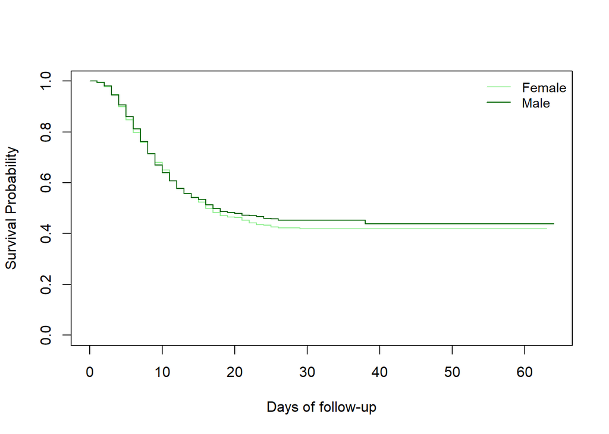

```r
#create the new survfit object based on gender
linelistsurv_fit_sex <-  survfit(

              Surv(futime, event) ~ gender, #formula to create the survival curve: ~ gender indicates we no longer plot the overall survival but based on gender
              data = linelist_surv #data to use
              )


#plot the survival curves by gender: have a look at the order of the strata level in the gender var before defining your colors
col_sex <- c("lightgreen", "darkgreen")

plot(linelistsurv_fit_sex,
     col=col_sex,
     xlab = "Days of follow-up",
     ylab="Survival Probability"
     )

legend("topright",
       legend=c("Female","Male"),
       col =col_sex,
       lty = 1, cex=.9, bty = "n"
       )
```

```r
#compute the test of the difference between the survival curves
survival::survdiff(
          Surv(futime, event) ~ gender,
          data = linelist_surv
         )
```

```
## Call:
## survival::survdiff(formula = Surv(futime, event) ~ gender, data = linelist_surv)
##
## n=4321, 218 observations deleted due to missingness.
##
##             N Observed Expected (O-E)^2/E (O-E)^2/V
## gender=f 2156      924      909     0.255     0.524
## gender=m 2165      929      944     0.245     0.524
##
##  Chisq= 0.5  on 1 degrees of freedom, p= 0.5
```

Some packages allow illustrating survival curves for different groups and testing the difference at once. Using the `ggsurvplot()` function from the *survminer* package, we can add in our curve the print of the risk tables for each group as well the p-value from the log-rank test.

We find back the p-value that was found in the previous step.

*CAUTION:* **survminer** functions require since the latest versions, specifying again the data used to fit the survival object. Remember doing this to avoid non-specific error messages.

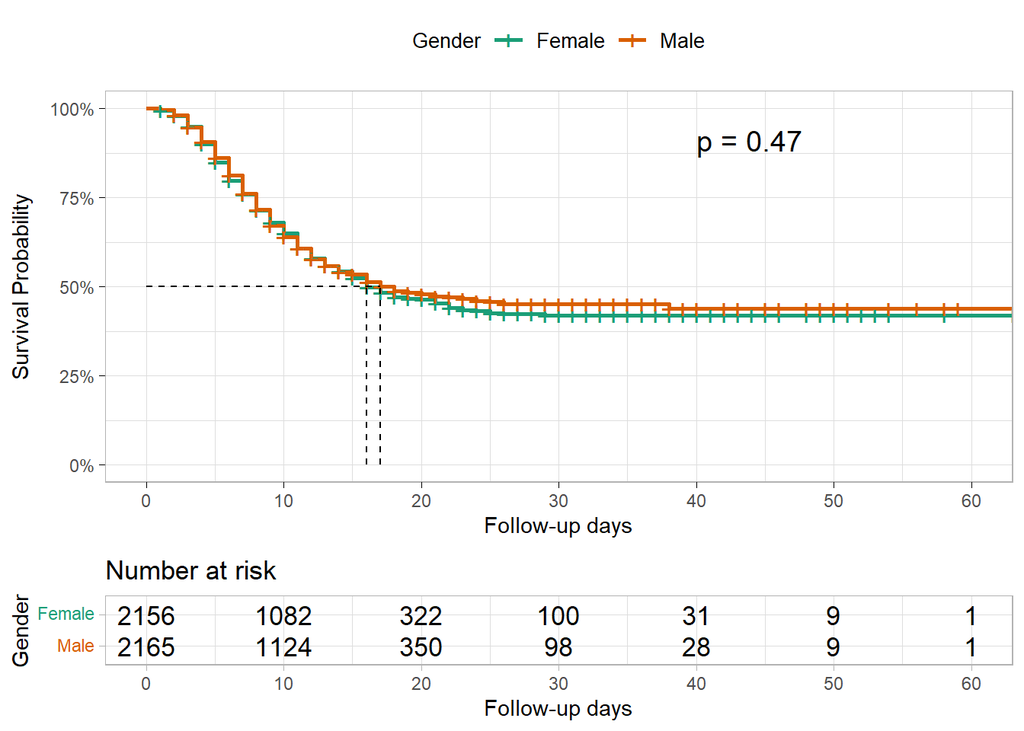

```r
survminer::ggsurvplot(

    linelistsurv_fit_sex,
    data= linelist_surv, #precise again the data used to fit the linelistsurv_fit_sex even though it is already precised in that object
    conf.int = F, #do not show confidence interval of KM estimates
    surv.scale = "percent",  #present probabilities in the y axis in %
    break.time.by=10, #present the time axis with an increment of 10 days
    xlab = "Follow-up days", ylab= "Survival Probability",
    pval=T, pval.coord= c(40,.91),  #print p-value of Log-rank test and at the position with these coordinates
    risk.table=T,  #print the risk table
    legend.title = "Gender",
    legend.labs = c("Female","Male"), font.legend = 10, #legend characteristics
    palette = "Dark2", #existing palette name precised,
    surv.median.line = "hv", #draw a line to the median survival
    ggtheme = theme_light()
)
```

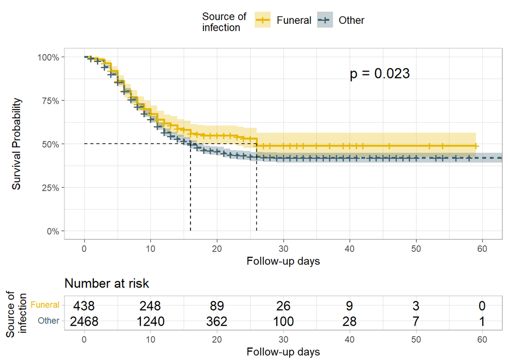

```r
linelistsurv_fit_source <-  survfit(
              Surv(futime, event) ~ source,
              data = linelist_surv
              )

ggsurvplot(
      linelistsurv_fit_source, data= linelist_surv,
      size=1, linetype = "strata",
      conf.int = T,
      surv.scale = "percent",
      break.time.by=10,
      xlab = "Follow-up days", ylab= "Survival Probability",
      pval=T, pval.coord= c(40,.91),
      risk.table=T,
      legend.title = "Source of \ninfection", legend.labs = c("Funeral","Other"),
      font.legend = 10,
      palette = c("#E7B800","#3E606F"),
      surv.median.line = "hv",
      ggtheme = theme_light()
)
```

## Cox regression analysis

Cox proportional hazards regression is one of the most popular regression techniques for survival analysis. Other models can also be used since the Cox model requires *important assumptions* that need to be verified for an appropriate use such as the proportional hazards assumption: see references.

In a Cox proportional hazards regression model, the measure of effect is the *hazard rate* (HR), which is the risk of failure (or the risk of death in our example), given that the participant has survived up to a specific time. Usually, we are interested in comparing *independent* groups with respect to their hazards, and we use a hazard ratio, which is analogous to an odds ratio in the setting of multiple logistic regression analysis. The `cox.ph()` from the **survival** package is used to fit the model. The function `cox.zph()` from **survival** package may be used to test the proportional hazards assumption for a Cox regression model fit.

*NOTE:* A probability must lie in the range 0 to 1. However, the hazard represents the expected number of events per one unit of time.

- If the hazard ratio for a predictor is close to 1 then that predictor does not affect survival,
- if the HR is less than 1, then the predictor is protective (i.e., associated with improved survival),
- and if the HR is greater than 1, then the predictor is associated with increased risk (or decreased survival).

### Fitting a Cox model

We can first fit a model to assess the effect of age and gender on the survival. By just printing the model, we have the information on:

- the estimated regression coefficients (`coef`) which quantifies the association between the predictors and the outcome,
- their exponential (for interpretability, `exp(coef)`) which produces the *hazard ratio*,
- their standard error (`se(coef)`),
- the z-score: how many standard errors is the estimated coefficient away from 0,
- and the p-value: the propability that the estimated coefficient could be 0.

The `summary()` function applied to the cox model object gives more info such as the confidence interval of the estimated HR and the different test scores.

The effect of the first covariate `gender` is presented in the first row. `genderm` is printed stating that the first strata level (`"f"`) i.e the female group is the reference group for the gender. Thus the interpretation of the test parameter is that of men compared to women. The p-value indicates there was no enough evidence of an effect of the gender on the expected hazard or of an association between gender and all-cause mortality.

The same lack of evidence is noted regarding age-group.

```r
#fitting the cox model
linelistsurv_cox_sexage <-  survival::coxph(
              Surv(futime, event) ~ gender + age_cat_small,
              data = linelist_surv
              )


#printing the model fitted
linelistsurv_cox_sexage
```

```
## Call:
## survival::coxph(formula = Surv(futime, event) ~ gender + age_cat_small,
##     data = linelist_surv)
##
##                       coef exp(coef) se(coef)      z     p
## genderm           -0.03149   0.96900  0.04767 -0.661 0.509
## age_cat_small5-19  0.09400   1.09856  0.06454  1.456 0.145
## age_cat_small20+   0.05032   1.05161  0.06953  0.724 0.469
##
## Likelihood ratio test=2.8  on 3 df, p=0.4243
## n= 4321, number of events= 1853
##    (218 observations deleted due to missingness)
```

```r
#summary of the model
summary(linelistsurv_cox_sexage)
```

```
## Call:
## survival::coxph(formula = Surv(futime, event) ~ gender + age_cat_small,
##     data = linelist_surv)
##
##   n= 4321, number of events= 1853
##    (218 observations deleted due to missingness)
##
##                       coef exp(coef) se(coef)      z Pr(>|z|)
## genderm           -0.03149   0.96900  0.04767 -0.661    0.509
## age_cat_small5-19  0.09400   1.09856  0.06454  1.456    0.145
## age_cat_small20+   0.05032   1.05161  0.06953  0.724    0.469
##
##                   exp(coef) exp(-coef) lower .95 upper .95
## genderm               0.969     1.0320    0.8826     1.064
## age_cat_small5-19     1.099     0.9103    0.9680     1.247
## age_cat_small20+      1.052     0.9509    0.9176     1.205
##
## Concordance= 0.514  (se = 0.007 )
## Likelihood ratio test= 2.8  on 3 df,   p=0.4
## Wald test            = 2.78  on 3 df,   p=0.4
## Score (logrank) test = 2.78  on 3 df,   p=0.4
```

It was interesting to run the model and look at the results but a first look to verify whether the proportional hazards assumptions is respected could help saving time.

```r
test_ph_sexage <- survival::cox.zph(linelistsurv_cox_sexage)
test_ph_sexage
```

```
##               chisq df    p
## gender        0.454  1 0.50
## age_cat_small 0.838  2 0.66
## GLOBAL        1.399  3 0.71
```

*NOTE:* A second argument called *method* can be specified when computing the cox model. It is the determines how ties are handled. The *default* is “efron”, and the other options are “breslow” and “exact”.

In another model we add more risk factors such as the source of infection and the number of days between date of onset and admission. This time, we first verify the proportional hazards assumption before going forward.

In this model, we have included a continuous predictor (`days_onset_hosp`). In this case we interpret the parameter estimates as the increase in the expected log of the relative hazard for each one unit increase in the predictor, holding other predictors constant. We first verify the proportional hazards assumption. The graphical verification of this assumption may be performed with the function `ggcoxzph()` from the *survminer* package.

```r
#fit the model
linelistsurv_cox <-  coxph(
                        Surv(futime, event) ~ gender + age_years+ source + days_onset_hosp,
                        data = linelist_surv
                        )


#test the proportional hazard model
linelistsurv_ph_test <- cox.zph(linelistsurv_cox)
linelistsurv_ph_test
```

```
##                    chisq df       p
## gender           0.45062  1    0.50
## age_years        0.00199  1    0.96
## source           1.79622  1    0.18
## days_onset_hosp 31.66167  1 1.8e-08
## GLOBAL          34.08502  4 7.2e-07
```

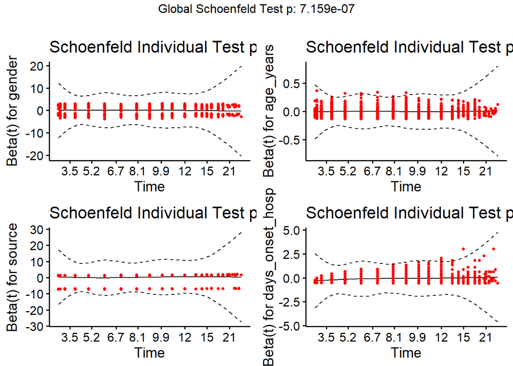

```r
survminer::ggcoxzph(linelistsurv_ph_test)
```

```r
#print the summary of the model
summary(linelistsurv_cox)
```

```
## Call:
## coxph(formula = Surv(futime, event) ~ gender + age_years + source +
##     days_onset_hosp, data = linelist_surv)
##
##   n= 2772, number of events= 1180
##    (1767 observations deleted due to missingness)
##
##                      coef exp(coef)  se(coef)      z Pr(>|z|)
## genderm          0.004710  1.004721  0.060827  0.077   0.9383
## age_years       -0.002249  0.997753  0.002421 -0.929   0.3528
## sourceother      0.178393  1.195295  0.084291  2.116   0.0343 *
## days_onset_hosp -0.104063  0.901169  0.014245 -7.305 2.77e-13 ***
## ---
## Signif. codes:  0 '***' 0.001 '**' 0.01 '*' 0.05 '.' 0.1 ' ' 1
##
##                 exp(coef) exp(-coef) lower .95 upper .95
## genderm            1.0047     0.9953    0.8918    1.1319
## age_years          0.9978     1.0023    0.9930    1.0025
## sourceother        1.1953     0.8366    1.0133    1.4100
## days_onset_hosp    0.9012     1.1097    0.8764    0.9267
##
## Concordance= 0.566  (se = 0.009 )
## Likelihood ratio test= 71.31  on 4 df,   p=1e-14
## Wald test            = 59.22  on 4 df,   p=4e-12
## Score (logrank) test = 59.54  on 4 df,   p=4e-12
```

### Forest plots

We can then visualize the results of the cox model using the practical forest plots with the `ggforest()` function of the **survminer package**.

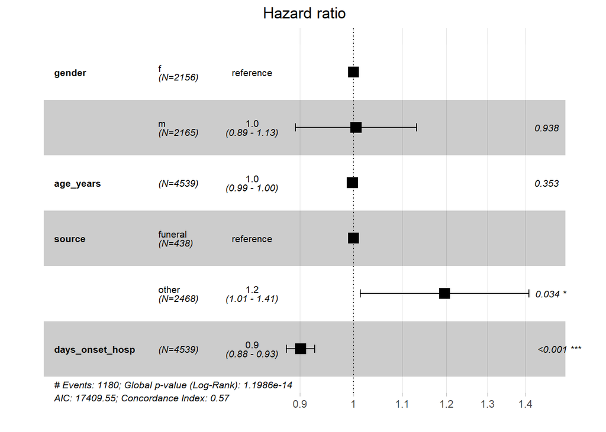

```r
ggforest(linelistsurv_cox, data = linelist_surv)
```

## Time-dependent covariates in survival models

Some of the following sections have been adapted with permission from an excellent [introduction to survival analysis in R](https://www.emilyzabor.com/tutorials/survival_analysis_in_r_tutorial.html) by [Dr. Emily Zabor](https://www.emilyzabor.com/)

In the last section we covered using Cox regression to examine associations between covariates of interest and survival outcomes.But these analyses rely on the covariate being measured at baseline, that is, before follow-up time for the event begins.

What happens if you are interested in a covariate that is measured **after** follow-up time begins? Or, what if you have a covariate that can change over time?

For example, maybe you are working with clinical data where you repeated measures of hospital laboratory values that can change over time. This is an example of a **Time Dependent Covariate**. In order to address this you need a special setup, but fortunately the cox model is very flexible and this type of data can also be modeled with tools from the **survival** package.

### Time-dependent covariate setup

Analysis of time-dependent covariates in R requires setup of a special dataset. If interested, see the more detailed paper on this by the author of the **survival** package [Using Time Dependent Covariates and Time Dependent Coefficients in the Cox Model](https://cran.r-project.org/web/packages/survival/vignettes/timedep.pdf).

For this, we’ll use a new dataset from the `SemiCompRisks` package named `BMT`, which includes data on 137 bone marrow transplant patients. The variables we’ll focus on are:

- `T1` - time (in days) to death or last follow-up
- `delta1` - death indicator; 1-Dead, 0-Alive
- `TA` - time (in days) to acute graft-versus-host disease
- `deltaA` - acute graft-versus-host disease indicator;
  - 1 - Developed acute graft-versus-host disease
  - 0 - Never developed acute graft-versus-host disease

```r
data(BMT, package = "SemiCompRisks")
```

#### Add unique patient identifier

There is no unique ID column in the `BMT` data, which is needed to create the type of dataset we want. So we use the function `rowid_to_column()` from the **tidyverse** package **tibble** to create a new id column called `my_id` (adds column at start of data frame with sequential row ids, starting at 1). We name the data frame `bmt`.

```r
bmt <- rowid_to_column(BMT, "my_id")
```

The dataset now looks like this:

| my_id | g | T1 | T2 | delta1 | delta2 | delta3 | TA | deltaA | TC | deltaC | TP | deltaP | Z1 | Z2 | Z3 | Z4 | Z5 | Z6 | Z7 | Z8 | Z9 | Z10 |
| --- | --- | --- | --- | --- | --- | --- | --- | --- | --- | --- | --- | --- | --- | --- | --- | --- | --- | --- | --- | --- | --- | --- |
| 1 | 1 | 2081 | 2081 | 0 | 0 | 0 | 67 | 1 | 121 | 1 | 13 | 1 | 26 | 33 | 1 | 0 | 1 | 1 | 98 | 0 | 1 | 0 |
| 2 | 1 | 1602 | 1602 | 0 | 0 | 0 | 1602 | 0 | 139 | 1 | 18 | 1 | 21 | 37 | 1 | 1 | 0 | 0 | 1720 | 0 | 1 | 0 |
| 3 | 1 | 1496 | 1496 | 0 | 0 | 0 | 1496 | 0 | 307 | 1 | 12 | 1 | 26 | 35 | 1 | 1 | 1 | 0 | 127 | 0 | 1 | 0 |
| 4 | 1 | 1462 | 1462 | 0 | 0 | 0 | 70 | 1 | 95 | 1 | 13 | 1 | 17 | 21 | 0 | 1 | 0 | 0 | 168 | 0 | 1 | 0 |
| 5 | 1 | 1433 | 1433 | 0 | 0 | 0 | 1433 | 0 | 236 | 1 | 12 | 1 | 32 | 36 | 1 | 1 | 1 | 1 | 93 | 0 | 1 | 0 |
| 6 | 1 | 1377 | 1377 | 0 | 0 | 0 | 1377 | 0 | 123 | 1 | 12 | 1 | 22 | 31 | 1 | 1 | 1 | 1 | 2187 | 0 | 1 | 0 |
| 7 | 1 | 1330 | 1330 | 0 | 0 | 0 | 1330 | 0 | 96 | 1 | 17 | 1 | 20 | 17 | 1 | 0 | 1 | 1 | 1006 | 0 | 1 | 0 |
| 8 | 1 | 996 | 996 | 0 | 0 | 0 | 72 | 1 | 121 | 1 | 12 | 1 | 22 | 24 | 1 | 0 | 0 | 0 | 1319 | 0 | 1 | 0 |
| 9 | 1 | 226 | 226 | 0 | 0 | 0 | 226 | 0 | 226 | 0 | 10 | 1 | 18 | 21 | 0 | 1 | 0 | 0 | 208 | 0 | 1 | 0 |
| 10 | 1 | 1199 | 1199 | 0 | 0 | 0 | 1199 | 0 | 91 | 1 | 29 | 1 | 24 | 40 | 1 | 1 | 0 | 1 | 174 | 0 | 3 | 1 |

[output cut: 127 more lines]

#### Expand patient rows

Next, we’ll use the `tmerge()` function with the `event()` and `tdc()` helper functions to create the restructured dataset. Our goal is to restructure the dataset to create a separate row for each patient for each time interval where they have a different value for `deltaA`. In this case, each patient can have at most two rows depending on whether they developed acute graft-versus-host disease during the data collection period. We’ll call our new indicator for the development of acute graft-versus-host disease `agvhd`.

- `tmerge()` creates a long dataset with multiple time intervals for the different covariate values for each patient
- `event()` creates the new event indicator to go with the newly-created time intervals
- `tdc()` creates the time-dependent covariate column, `agvhd`, to go with the newly created time intervals

```r
td_dat <-
  tmerge(
    data1 = bmt %>% select(my_id, T1, delta1),
    data2 = bmt %>% select(my_id, T1, delta1, TA, deltaA),
    id = my_id,
    death = event(T1, delta1),
    agvhd = tdc(TA)
    )
```

To see what this does, let’s look at the data for the first 5 individual patients.

The variables of interest in the original data looked like this:

```r
bmt %>%
  select(my_id, T1, delta1, TA, deltaA) %>%
  filter(my_id %in% seq(1, 5))
```

```
##   my_id   T1 delta1   TA deltaA
## 1     1 2081      0   67      1
## 2     2 1602      0 1602      0
## 3     3 1496      0 1496      0
## 4     4 1462      0   70      1
## 5     5 1433      0 1433      0
```

The new dataset for these same patients looks like this:

```r
td_dat %>%
  filter(my_id %in% seq(1, 5))
```

```
##   my_id   T1 delta1 id tstart tstop death agvhd
## 1     1 2081      0  1      0    67     0     0
## 2     1 2081      0  1     67  2081     0     1
## 3     2 1602      0  2      0  1602     0     0
## 4     3 1496      0  3      0  1496     0     0
## 5     4 1462      0  4      0    70     0     0
## 6     4 1462      0  4     70  1462     0     1
## 7     5 1433      0  5      0  1433     0     0
```

Now some of our patients have two rows in the dataset corresponding to intervals where they have a different value of our new variable, `agvhd`. For example, Patient 1 now has two rows with a `agvhd` value of zero from time 0 to time 67, and a value of 1 from time 67 to time 2081.

### Cox regression with time-dependent covariates

Now that we’ve reshaped our data and added the new time-dependent `aghvd` variable, let’s fit a simple single variable cox regression model. We can use the same `coxph()` function as before, we just need to change our `Surv()` function to specify both the start and stop time for each interval using the `time1 =` and `time2 =` arguments.

```r
bmt_td_model = coxph(
  Surv(time = tstart, time2 = tstop, event = death) ~ agvhd,
  data = td_dat
  )

summary(bmt_td_model)
```

```
## Call:
## coxph(formula = Surv(time = tstart, time2 = tstop, event = death) ~
##     agvhd, data = td_dat)
##
##   n= 163, number of events= 80
##
##         coef exp(coef) se(coef)    z Pr(>|z|)
## agvhd 0.3351    1.3980   0.2815 1.19    0.234
##
##       exp(coef) exp(-coef) lower .95 upper .95
## agvhd     1.398     0.7153    0.8052     2.427
##
## Concordance= 0.535  (se = 0.024 )
## Likelihood ratio test= 1.33  on 1 df,   p=0.2
## Wald test            = 1.42  on 1 df,   p=0.2
## Score (logrank) test = 1.43  on 1 df,   p=0.2
```

Again, we’ll visualize our cox model results using the `ggforest()` function from the **survminer package**.:

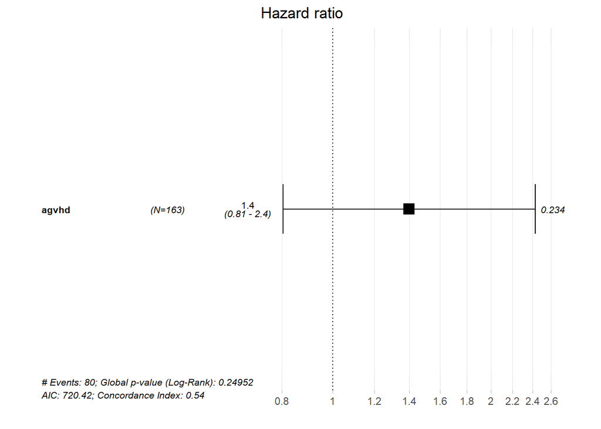

```r
ggforest(bmt_td_model, data = td_dat)
```

As you can see from the forest plot, confidence interval, and p-value, there does not appear to be a strong association between death and acute graft-versus-host disease in the context of our simple model.

## Resources

[Survival Analysis Part I: Basic concepts and first analyses](https://www.ncbi.nlm.nih.gov/pmc/articles/PMC2394262/)

[Paper on different survival measures for cancer registry data with Rcode provided as supplementary materials](https://www.ncbi.nlm.nih.gov/pmc/articles/PMC6322561/)

[Survival Analysis in R](https://www.emilyzabor.com/tutorials/survival_analysis_in_r_tutorial.html)

[Survival analysis in infectious disease research: Describing events in time](https://www.ncbi.nlm.nih.gov/pmc/articles/PMC2954271/)

[Survival analysis cheatsheet R](https://publicifsv.sund.ku.dk/~ts/survival/survival-cheat.pdf)

[Survminer cheastsheet](https://paulvanderlaken.files.wordpress.com/2017/08/survminer_cheatsheet.pdf)

[Chapter on advanced survival models Princeton](https://data.princeton.edu/wws509/notes/c7.pdf)

[Using Time Dependent Covariates and Time Dependent Coefficients in the Cox Model](https://cran.r-project.org/web/packages/survival/vignettes/timedep.pdf)